# AML data analysis

#### Libraries

```r
library(RColorBrewer)
set1 <- brewer.pal(8, "Set1")
col1 <- brewer.pal(9, "Set1")[c(1, 4, 3, 5, 7, 8, 2, 9)]
source("../../CoxHD/CoxHD/R/CoxRFX.R")
source("../../CoxHD/CoxHD/R/functions.R")
source("../../../../Projects/sandbox/mg14.R")
```

## 1. Load data

### Clinical

Loading

```r
clinicalData <- read.table("../data/Ulm1.8_sm_Clinical.txt", sep="\t", header=TRUE, na.strings = "na", comment.char = "", quote="\"")
clinicalData <- clinicalData[order(clinicalData$PDID),]
clinicalData$ERDate <- as.Date(as.character(clinicalData$ERDate), "%d-%b-%y")
clinicalData$CR_date <- as.Date(as.character(clinicalData$CR_date), "%d-%b-%y")
clinicalData$TPL_date <- as.Date(as.character(clinicalData$TPL_date), "%d-%b-%y")
clinicalData$Date_LF <- as.Date(as.character(clinicalData$Date_LF), "%d-%b-%y")
clinicalData$Recurrence_date <- as.Date(as.character(clinicalData$Recurrence_date), "%d-%b-%y")
levels(clinicalData$Study) <- c( "tr98A" ,   "tr98B" ,   "tr0704")
clinicalData$VPA[is.na(clinicalData$VPA)] <- 0
clinicalData$ATRA_arm[is.na(clinicalData$ATRA_arm)] <- 0
colnames(clinicalData) <- gsub('\\.',"",colnames(clinicalData))
dim(clinicalData)
```

```
## [1] 1576  120
```

### Mutation data

```r
mutationData = read.table("../data/Ulm1.8_sm_Genetic.txt", sep = "\t", header = TRUE, strip.white = TRUE)
mutationData$SAMPLE_NAME <- factor(as.character(mutationData$SAMPLE_NAME), levels = levels(clinicalData$PDID))  ## Refactor
mutationTable <- (table(mutationData[mutationData$Result %in% c("ONCOGENIC", "POSSIBLE") & mutationData$FINAL_CALL == "OK",
    c("SAMPLE_NAME", "GENE")]) > 0) + 0
dim(mutationTable)
```

```
## [1] 1576   56
```

```r
all(rownames(mutationTable) == clinicalData$PDID)
```

```
## [1] TRUE
```

#### A few functions

```r
makeInteractions
```

```
## function(X,Y){
##  Z <- do.call(cbind, lapply(X, `*`, Y))
##  colnames(Z) <- apply(expand.grid(colnames(Y), colnames(X)),1,paste, collapse=":")
##  return(Z)
## }
```

```r
makeInteger
```

```
## function(F){
##  res <- as.data.frame(lapply(levels(F), `==`, F))
##  colnames(res) <- levels(F)
##  res + 0
## }
```

```r
trialArms <- makeInteger(clinicalData$Study)
```

## 2. Preparing data

#### Survival object

```r
library(survival)
survival <- Surv(clinicalData$efs, clinicalData$EFSSTAT)  #EFS
tplIdx <- (clinicalData$Time_Diag_TPL < clinicalData$efs & !is.na(clinicalData$Time_Diag_TPL)) | (is.na(clinicalData$efs &
    !is.na(clinicalData$Time_Diag_TPL)))
```

#### All data as list

```r
dataList <- list(Genetics = data.frame(mutationTable[, colSums(mutationTable) > 0]), Cytogenetics = clinicalData[, c(47:53,
    55:71)], Treatment = cbind(trialArms[, 2:3], ATRA = clinicalData$ATRA_arm, VPA = clinicalData$VPA, TPL = tplIdx), Clinical = cbind(clinicalData[,
    c("AOD", "gender", "Performance_ECOG", "BM_Blasts", "PB_Blasts", "wbc", "LDH_", "HB", "platelet", "Splenomegaly")], makeInteger(clinicalData$TypeAML)[,
    -1]))  #,
# MolRisk = makeInteger(clinicalData$M_Risk)) dataList$Genetics$CEBPA <- clinicalData$CEBPA # encoded as 0,1,2
dataList$Genetics$CEBPA_mono <- clinicalData$CEBPA == 1  # encoded as 0,1,2
dataList$Genetics$CEBPA_bi <- clinicalData$CEBPA == 2  # encoded as 0,1,2
dataList$Genetics$CEBPA <- NULL
dataList$Genetics$FLT3 <- NULL
dataList$Genetics$FLT3_ITD <- clinicalData$ITD != "0"
dataList$Genetics$FLT3_TKD <- clinicalData$TKD != "0"
dataList$Genetics$IDH2_p172 <- clinicalData$IDH2 == "172"
dataList$Genetics$NPM1 <- clinicalData$NPM1
dataList$Genetics$MLL_PTD <- clinicalData$MLL_PTD
dataList$Cytogenetics$MLL_PTD <- NULL
dataList$Genetics = dataList$Genetics + 0
dataList$GeneGene <- makeInteractions(data.frame(dataList$Genetics), data.frame(dataList$Genetics))[, as.vector(upper.tri(matrix(0,
    ncol = ncol(dataList$Genetics), nrow = ncol(dataList$Genetics))))]
dataList$GeneGene <- dataList$GeneGene[, colSums(dataList$GeneGene, na.rm = TRUE) > 0]
dataList$GeneCyto <- makeInteractions(dataList$Genetics, dataList$Cytogenetics)
dataList$GeneCyto <- dataList$GeneCyto[, colSums(dataList$GeneCyto, na.rm = TRUE) > 0]
dataList$GeneTreat <- makeInteractions(dataList$Genetics, dataList$Treatment[c("TPL", "ATRA", "VPA")])
dataList$GeneTreat <- dataList$GeneTreat[, colSums(dataList$GeneTreat, na.rm = TRUE) > 0]
dataList$CytoTreat <- makeInteractions(dataList$Cytogenetics, dataList$Treatment[c("TPL", "ATRA", "VPA")])
dataList$CytoTreat <- dataList$CytoTreat[, colSums(dataList$CytoTreat, na.rm = TRUE) > 0]
```

#### Condensing to a data.frame

```r
dataFrame <- do.call(cbind, dataList)
dataFrame <- StandardizeMagnitude(dataFrame)
names(dataFrame) <- unlist(sapply(dataList, names))
dim(dataFrame)
```

```
## [1] 1576 1534
```

```r
groups <- factor(unlist(sapply(names(dataList), function(x) rep(x, ncol(dataList[[x]])))))
table(groups)
```

```
## groups
##     Clinical    CytoTreat Cytogenetics     GeneCyto     GeneGene    GeneTreat     Genetics    Treatment
##           13           65           24          537          691          141           58            5
```

Poor man's imputation

```r
poorMansImpute <- function(x) {
    x[is.na(x)] <- mean(x, na.rm = TRUE)
    return(x)
}
dataFrame <- as.data.frame(sapply(dataFrame, poorMansImpute))
```

Compute gene:gene interactions

```r
data <- cbind(dataList$Genetics, dataList$Cytogenetics)
data <- data[, colSums(data, na.rm = TRUE) >= 16]
dim(data)
```

```
## [1] 1576   55
```

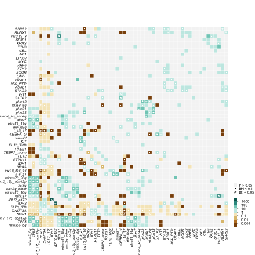

```r
interactions <- sapply(1:ncol(data), function(i) sapply(1:ncol(data), function(j) {
    f <- try(fisher.test(data[, i], data[, j]), silent = TRUE)
    if (class(f) == "try-error")
        0 else ifelse(f$estimate > 1, -log10(f$p.val), log10(f$p.val))
}))
odds <- sapply(1:ncol(data), function(i) sapply(1:ncol(data), function(j) {
    f <- try(fisher.test(data[, i] + 0.5, data[, j] + 0.5), silent = TRUE)
    if (class(f) == "try-error")
        f = NA else f$estimate
}))
diag(interactions) <- 0
diag(odds) <- 1
colnames(odds) <- rownames(odds) <- colnames(interactions) <- rownames(interactions) <- colnames(data)
odds[10^-abs(interactions) > 0.05] = 1
odds[odds < 0.001] = 1e-04
odds[odds > 1000] = 10000
logodds = log10(odds)

# pdf(paste(Sys.Date(),'-Interactions.pdf', sep=''), 4,4, pointsize = 8) ## HEATMAP OF ALL
par(bty = "n", mgp = c(2, 0.5, 0), mar = c(3, 3, 2, 2) + 0.1, las = 2, tcl = -0.33)
ix = TRUE  #colnames(interactions) %in% colnames(all_genotypes)
h = hclust(dist(interactions[ix, ix]))
o = h$order  #c(h$order,(length(h$order) +1):ncol(interactions))
# image(x=1:ncol(interactions), y=1:nrow(interactions), interactions[o,o], col=brewer.pal(11,'BrBG'), breaks = c(-100,
# seq(-9,9,2), 100), xaxt='n', yaxt='n', xlab='',ylab='', xlim=c(0, ncol(interactions)+3), ylim=c(0,
# ncol(interactions)+3))
image(x = 1:ncol(interactions), y = 1:nrow(interactions), log10(odds[o, o]), col = brewer.pal(9, "BrBG"), breaks = c(-4:0 -
    .Machine$double.eps, 0:4), xaxt = "n", yaxt = "n", xlab = "", ylab = "", xlim = c(0, ncol(interactions) + 3), ylim = c(0,
    ncol(interactions) + 3))
mtext(side = 1, at = 1:ncol(interactions), colnames(interactions)[o], cex = 0.5, font = 3)
mtext(side = 2, at = 1:ncol(interactions), colnames(interactions)[o], cex = 0.5, font = 3)
abline(h = length(h$order) + 0.5, col = "white", lwd = 1)
abline(v = length(h$order) + 0.5, col = "white", lwd = 1)
abline(h = 0:ncol(interactions) + 0.5, col = "white", lwd = 0.5)
abline(v = 0:ncol(interactions) + 0.5, col = "white", lwd = 0.5)
w = arrayInd(which(p.adjust(10^-abs(interactions[o, o]), method = "BH") < 0.1), rep(nrow(interactions), 2))
points(w, pch = ".", col = "white")
w = arrayInd(which(p.adjust(10^-abs(interactions[o, o])) < 0.05), rep(nrow(interactions), 2))
points(w, pch = "*", col = "white")
image(y = 1:8, x = rep(ncol(interactions), 2) + c(2, 3), z = matrix(c(1:8), nrow = 1), col = brewer.pal(8, "BrBG"), add = TRUE)
# axis(side = 4, at = 8:12 + .5, cex.axis=.5, tcl=-.15, label=10^-abs(seq(1,9,2)), las=1, lwd=.5) axis(side = 4, at =
# 1:5 + .5, cex.axis=.5, tcl=-.15, label=10^-abs(seq(-9,-1,2)), las=1, lwd=.5)
axis(side = 4, at = seq(1, 7) + 0.5, cex.axis = 0.5, tcl = -0.15, label = 10^seq(-3, 3), las = 1, lwd = 0.5)
# lines(rep(ncol(interactions),2)+c(1,4), c(6,6)+.5, col='white') mtext(side=4, at=-1, 'P odds < 1', cex=.5, line=-.5)
# mtext(side=4, at=15, 'P odds > 1', cex=.5, line=-.5)
points(x = rep(ncol(interactions), 2) + 2.5, y = 10:11, pch = c("*", "."))
image(x = rep(ncol(interactions), 2) + c(2, 3), y = (12:13) - 0.5, z = matrix(1), col = brewer.pal(3, "BrBG"), add = TRUE)
mtext(side = 4, at = 12:10, c("P > 0.05", "BH < 0.1", "Bf. < 0.05"), cex = 0.5, line = 0.2)
```

```r
# dev.off()
```

## 3. Survival analyses

### 0. Proportional hazards test

```r
coxModel <- coxph(survival ~ gender + AOD + Study, data = clinicalData)  # Most basic
phTest <- cox.zph(coxModel)
phTest
```

```
##                 rho chisq      p
## gender      -0.0154 0.271 0.6026
## AOD          0.0318 1.244 0.2648
## Studytr98B   0.0374 1.644 0.1998
## Studytr0704  0.0579 3.818 0.0507
## GLOBAL           NA 8.494 0.0751
```

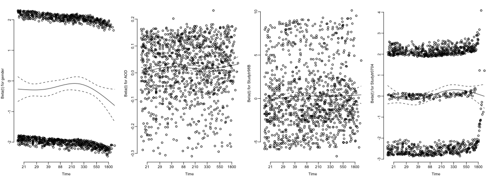

```r
par(mfrow = c(1, 4), bty = "n")
for (i in 1:4) plot(phTest[i])
```

### 1. Random effects: static model

```r
## Pre-select based on univariate test univP <- sapply(dataFrame, function(x){summary(coxph(survival~x))$logtest[3]})
## whichRFX <- which(p.adjust(univP,'BH') < 0.1 | groups %in% c('Genetics','Treatment','Clinical','Cytogenetics'))
mainGroups <- c("Genetics", "Treatment", "Clinical", "Cytogenetics")
mainIdx <- groups %in% mainGroups
whichRFX <- which(colSums(dataFrame) >= 8 | mainIdx)  # ie, > 0.5%

## Fit Cox model
coxRFXFit <- CoxRFX(dataFrame[, whichRFX], survival, groups = groups[whichRFX], sigma0 = 0.1, nu = 0)
# coxRFXFit <- CoxRFX(dataFrame[,whichRFX], survival, groups=groups[whichRFX], sigma0=0.01) ## reassuring that sigma
# doesn't shrink further
```

Coefficients

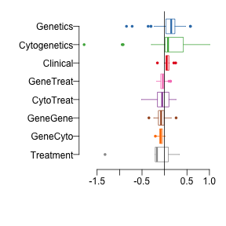

```r
par(mar = c(5, 7, 1, 1))
o <- order(coxRFXFit$mu)
boxplot(coef(coxRFXFit) ~ factor(coxRFXFit$groups, levels = levels(groups)[o]), border = col1[o], horizontal = TRUE, las = 1,
    lty = 1, pch = 16, cex = 0.66, staplewex = 0)
abline(v = 0)
```

### 2. Random effects: Time-dependent model (TPL)

Construct a time-dependent Surv() object by splitting TPL patients into pre and post

```r
t <- clinicalData$Time_Diag_TPL
t[is.na(t)] <- Inf
e <- clinicalData$efs
tplIndex <- t < e
survivalTD <- Surv(time = rep(0, nrow(clinicalData)), time2 = pmin(e, t), event = ifelse(tplIndex, 0, clinicalData$EFSSTAT))
survivalTD <- rbind(survivalTD, Surv(time = t[which(tplIndex)], time2 = e[which(tplIndex)], event = clinicalData$EFSSTAT[which(tplIndex)]))
survivalTD = Surv(survivalTD[, 1], survivalTD[, 2], survivalTD[, 3])
rm(e, t)
tplSplit <- c(1:nrow(clinicalData), which(tplIndex))
```

Construct data.frame

```r
dataFrameTD <- dataFrame[tplSplit, ]
dataFrameTD[which(tplIndex), grep("TPL", colnames(dataFrameTD), value = TRUE)] <- 0  ## Set pre-tpl variables to zero

patientTD <- c(clinicalData$PDID, clinicalData$PDID[which(tplIndex)])
```

Fit TD Cox RFX model

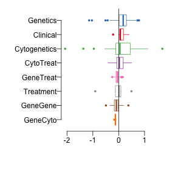

```r
# whichRFXTD <- which(p.adjust(univP,'BH') < 0.1 | groups %in% c('Genetics','Treatment','Clinical','Cytogenetics'))
whichRFXTD <- which(colSums(dataFrame) >= 8 | mainIdx)

coxRFXFitTD <- CoxRFX(dataFrameTD[, whichRFXTD], survivalTD, groups[whichRFXTD], sigma0 = 0.1, nu = 0)

par(mar = c(5, 7, 1, 1))
o <- order(coxRFXFitTD$mu)
boxplot(coef(coxRFXFitTD)/log(2) ~ factor(coxRFXFitTD$groups, levels = levels(groups)[o]), border = col1[o], horizontal = TRUE,
    las = 1, lty = 1, pch = 16, cex = 0.66, staplewex = 0)
abline(v = 0)
```

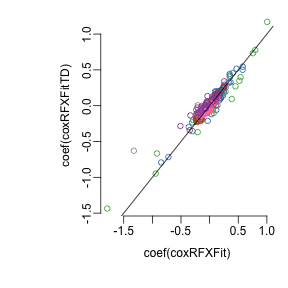

```r
plot(coef(coxRFXFit), coef(coxRFXFitTD), col = col1[groups[whichRFXTD]])  # Note the sign change for TPL..
abline(0, 1)
```

#### Coefficient estimates (MAP)

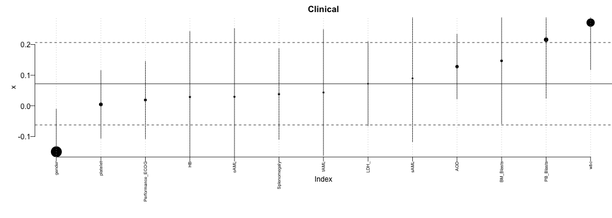

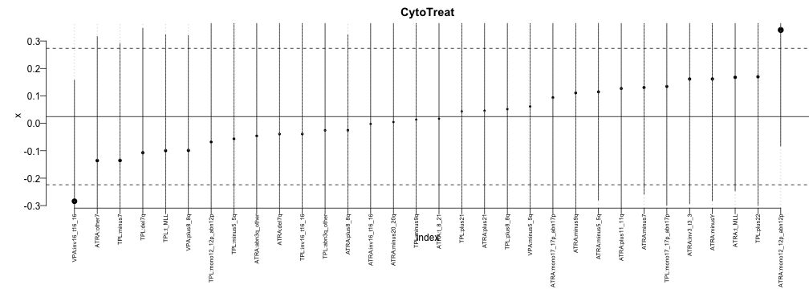

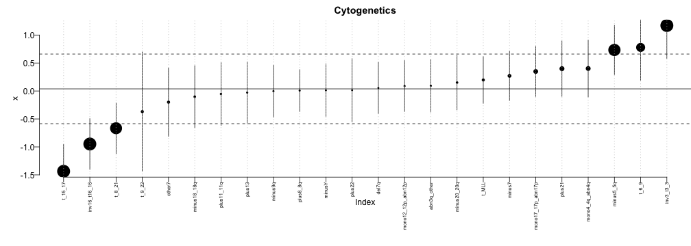

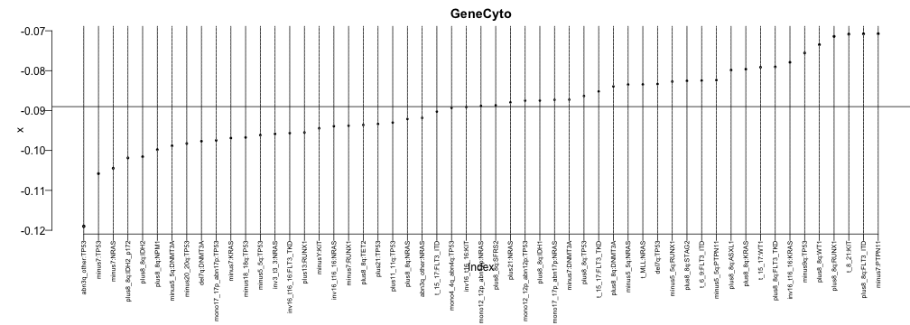

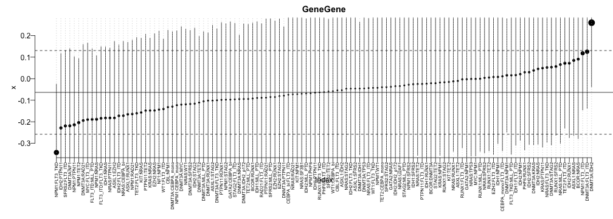

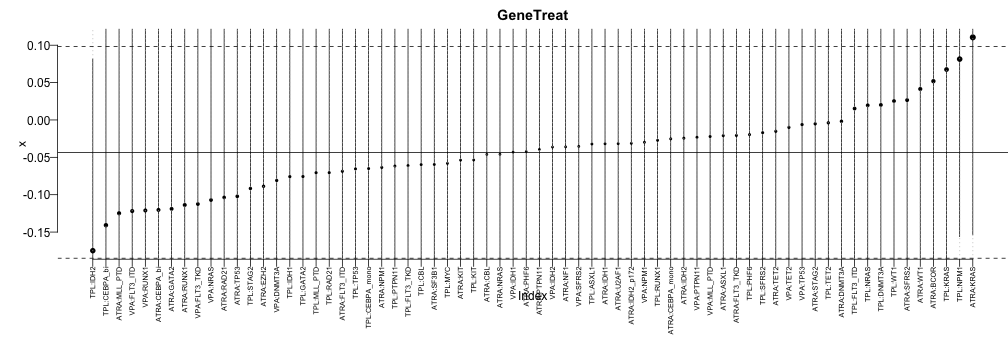

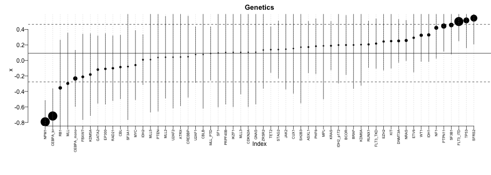

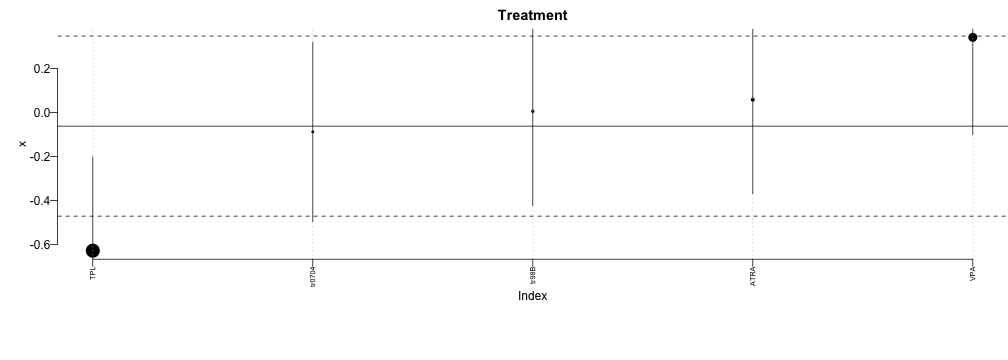

```r
for (g in levels(groups)) {
    par(mar = c(7, 4, 2, 0))
    x <- sort(coxRFXFitTD$coefficients[groups[whichRFXTD] == g])
    v <- diag(coxRFXFitTD$var)[groups[whichRFXTD] == g][order(coxRFXFitTD$coefficients[groups[whichRFXTD] == g])]
    plot(x, las = 2, pch = 16, xaxt = "n", main = g, cex = 0.5 + pmin(3, -log10(pchisq((x - coxRFXFitTD$mu[g])^2/v, 1, lower.tail = FALSE))))
    segments(1:length(x), x - 2 * sqrt(v), 1:length(x), x + 2 * sqrt(v))
    axis(side = 1, at = 1:length(x), labels = names(x), las = 2, cex.axis = 0.6)
    abline(v = 1:length(x), lty = 3, col = "grey")
    abline(h = coxRFXFitTD$mu[g])
    abline(h = coxRFXFitTD$mu[g] + c(-1, 1) * sqrt(coxRFXFitTD$sigma2[g]), lty = 2)
}
```

#### Partial risk contributions

```r
partRiskTD <- PartialRisk(coxRFXFitTD)
# varianceComponents <- rowSums(cov(partRiskTD, use='complete'))
varianceComponents <- diag(cov(partRiskTD, use = "complete"))
varianceComponents
```

```
##     Clinical    CytoTreat Cytogenetics     GeneCyto     GeneGene    GeneTreat     Genetics    Treatment
##     0.069630     0.004527     0.251207     0.011282     0.047262     0.007967     0.220330     0.065315
```

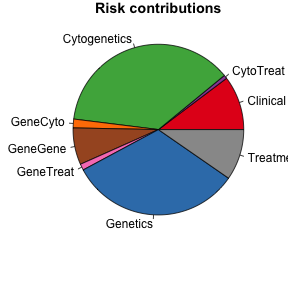

```r
pie(abs(varianceComponents), col = col1)
title("Risk contributions")
```

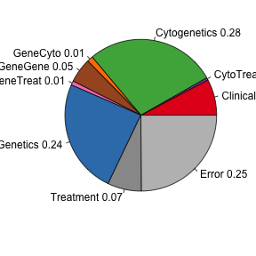

```r
partRiskVar <- PartialRiskVar(coxRFXFitTD)
x = c(varianceComponents, Error = mean(rowSums(partRiskVar)))
pie(x, col = c(col1, "grey"), labels = paste(names(x), round(x/sum(x), 2)))
```

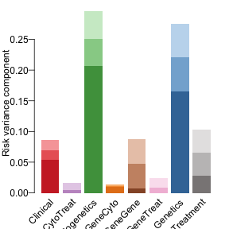

```r
m <- colMeans(partRiskVar)
barplot(varianceComponents + m, border = NA, col = colTrans(col1), las = 2, xaxt = "n", ylab = "Risk variance component")
barplot(varianceComponents, border = NA, col = colTrans(col1, 1), add = TRUE, xaxt = "n", yaxt = "n")
b <- barplot(pmax(0, varianceComponents - m), border = NA, col = colTrans(col1, 0), add = TRUE, xaxt = "n", yaxt = "n")
rotatedLabel(b, rep(0, 8), names(varianceComponents), srt = 45)
```

[figure not shown]

```r
o <- order(varianceComponents)
stars(matrix(varianceComponents[o], nrow = 1) + m, draw.segments = TRUE, col.segments = colTrans(col1)[o], scale = FALSE,
    col.lines = 0, lty = 0, labels = "")
stars(matrix(varianceComponents[o], nrow = 1), draw.segments = TRUE, col.segments = colTrans(col1, 1)[o], scale = FALSE,
    col.lines = 0, lty = 0, labels = "", add = TRUE)
stars(matrix(pmax(0, varianceComponents[o] - m), nrow = 1), draw.segments = TRUE, col.segments = col1[o], scale = FALSE,
    col.lines = 0, lty = 0, labels = "", add = TRUE)
```

#### Stars

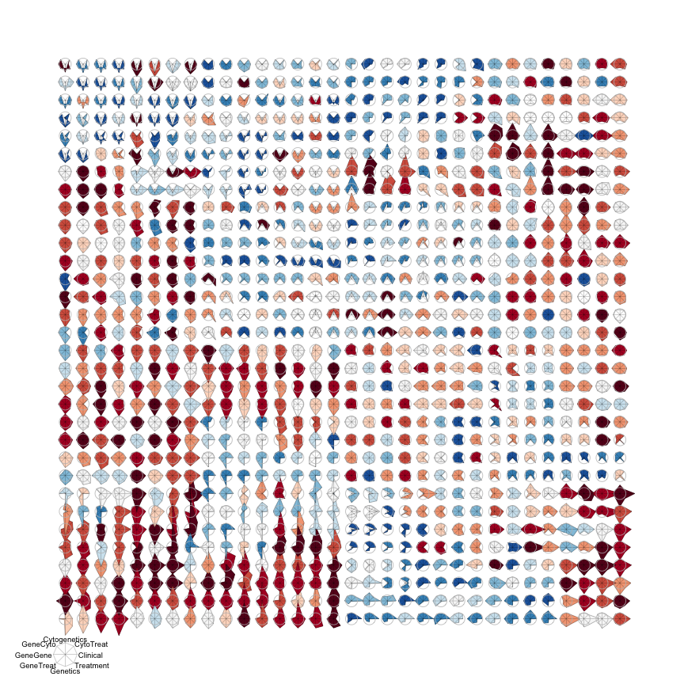

```r
library(HilbertVis)
nStars <- 32
locations <- 1.5 * hilbertCurve(log2(nStars))  #2*expand.grid(1:nStars,1:nStars)
s <- sample(nrow(partRiskTD), nStars^2)  #1:(nStars^2)
h <- hclust(dist(partRiskTD[s, ]))
# stars(exp((partRisk[s,][h$order,] - rep(colMeans(partRisk), each=nStars^2)))/2, scale=FALSE, locations=locations,
# key.loc=c(0,-3), col.lines=rep(1,(nStars^2)), col.stars = brewer.pal(11,'RdBu')[cut(survivalTD[s,2][h$order],
# quantile(survivalTD[,2], seq(0,1,0.1), na.rm=TRUE))])
x <- partRiskTD - rep(colMeans(partRiskTD), each = nrow(partRiskTD))
x <- x/(2 * sd(x)) + 1
# x <- exp(x)
stars(x[s, ][h$order, ]/2, scale = FALSE, locations = locations, key.loc = c(0, -3), col.lines = rep(1, (nStars^2)), col.stars = (brewer.pal(11,
    "RdBu"))[cut(survivalTD[s, 2][h$order], quantile(survivalTD[, 2], seq(0, 1, 0.1), na.rm = TRUE))])
symbols(locations[, 1], locations[, 2], circles = rep(0.5, (nStars^2)), inches = FALSE, fg = "grey", add = TRUE, lty = 1)
```

#### Harrel's C

```r
# library(Hmisc)
totalRiskTD <- rowSums(partRiskTD)
survConcordance(survivalTD ~ totalRiskTD)
```

```
## Call:
## survConcordance(formula = survivalTD ~ totalRiskTD)
##
##   n=1876 (31 observations deleted due to missingness)
## Concordance= 0.7309 se= 0.0092
## concordant discordant  tied.risk  tied.time   std(c-d)
##     789602     290783          0       3500      19879
```

```r
predictiveRiskTD <- rowSums(partRiskTD[, -which(colnames(partRiskTD) %in% c("Treatment", "GeneTreat", "CytoTreat"))])
survConcordance(survivalTD ~ predictiveRiskTD)
```

```
## Call:
## survConcordance(formula = survivalTD ~ predictiveRiskTD)
##
##   n=1876 (31 observations deleted due to missingness)
## Concordance= 0.7191 se= 0.0092
## concordant discordant  tied.risk  tied.time   std(c-d)
##     776907     303478          0       3500      19879
```

#### Genomic risk

```r
whichGenomic <- which(!colnames(partRiskTD) %in% c("Treatment", "GeneTreat", "CytoTreat", "Clinical"))
genomicRiskTD <- rowSums(partRiskTD[, whichGenomic])
survConcordance(survivalTD ~ genomicRiskTD)
```

```
## Call:
## survConcordance(formula = survivalTD ~ genomicRiskTD)
##
##   n=1876 (31 observations deleted due to missingness)
## Concordance= 0.7079 se= 0.0092
## concordant discordant  tied.risk  tied.time   std(c-d)
##     763644     314487       2254       3500      19878
```

#### AUC

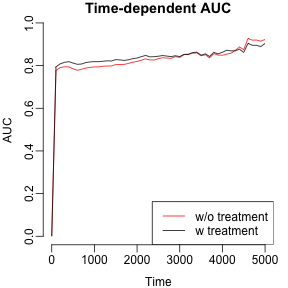

```r
library(survAUC)
s <- survival
plot(AUC.uno(s[!is.na(s)], s[!is.na(s)], genomicRiskTD[!is.na(s)], seq(0, 5000, 100)))
plot(AUC.uno(s[!is.na(s)], s[!is.na(s)], totalRiskTD[!is.na(s)], seq(0, 5000, 100)), add = TRUE, col = "black")
legend("bottomright", c("w/o treatment", "w treatment"), col = 2:1, lty = 1)
```

#### Genomic risk groups

```r
genomicRiskGroups <- cut(genomicRiskTD[!is.na(genomicRiskTD)], quantile(genomicRiskTD, seq(0, 1, 0.25)), labels = c("very low",
    "low", "high", "very high"))
survConcordance(survivalTD ~ as.numeric(genomicRiskGroups))
```

```
## Call:
## survConcordance(formula = survivalTD ~ as.numeric(genomicRiskGroups))
##
##   n=1875 (32 observations deleted due to missingness)
## Concordance= 0.6911 se= 0.008843
## concordant discordant  tied.risk  tied.time   std(c-d)
##     617045     204596     257631       3500      19088
```

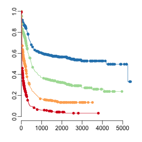

```r
plot(survfit(survivalTD[!is.na(genomicRiskTD)] ~ genomicRiskGroups), col = brewer.pal(4, "Spectral")[4:1], mark = 16)
```

```r
table(clinicalData$M_Risk, genomicRiskGroups[1:nrow(clinicalData)])[c(2, 3, 4, 1), ]
```

```
##
##             very low low high very high
##   Favorable      319 139   17         0
##   inter-1         15 115  170       117
##   inter-2         36  60   92        81
##   Adverse          1   9   53       192
```

Risk Plots

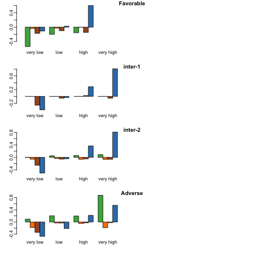

```r
par(mfrow = c(4, 1))
i <- 0
for (l in levels(clinicalData$M_Risk)[c(2, 3, 4, 1)]) {
    barplot(sapply(split(as.data.frame(partRiskTD[1:nrow(clinicalData), whichGenomic][clinicalData$M_Risk == l, ]), genomicRiskGroups[1:nrow(clinicalData)][clinicalData$M_Risk ==
        l]), colMeans), beside = TRUE, legend = i == 4, col = col1[whichGenomic], main = l, xlim = c(1, 45))
    i <- i + 1
}
```

Partial values of Harrel's C

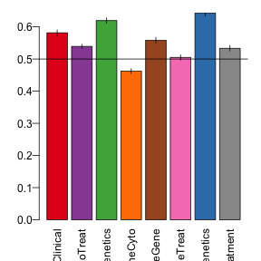

```r
c <- PartialC(coxRFXFitTD)
b <- barplot(c[1, ], col = col1, las = 2)
segments(b, c[1, ] - c[2, ], b, c[1, ] + c[2, ])
abline(h = 0.5)
```

## 4. Cross-validation

Train only on 2/3 of the data

```r
set.seed(42)
trainIdx <- sample(c(TRUE, FALSE), nrow(dataFrame), replace = TRUE, prob = c(0.66, 0.34))
trainIdxTD <- trainIdx[tplSplit]
```

Pre-select based on univariate test

```r
# p <- sapply(dataFrame, function(x){summary(coxph(survivalTD[trainIdxTD]~x[trainIdxTD]))$logtest[3]})
whichTrain <- whichRFXTD
```

### 1. Static random effects model

```r
coxRFXFitTrain <- CoxRFX(dataFrame[trainIdx, whichTrain], survival[trainIdx], groups = groups[whichTrain], sigma0 = 0.1,
    nu = 0)
```

### 2. Time-dependent random effects model

```r
coxRFXFitTDTrain <- CoxRFX(dataFrameTD[trainIdxTD, whichTrain], survivalTD[trainIdxTD], groups = groups[whichTrain], sigma0 = 0.1,
    nu = 0)
```

Partial contributions

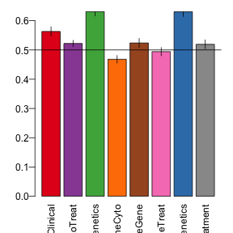

```r
partialRiskTest <- PartialRisk(coxRFXFitTDTrain, newX = dataFrameTD[!trainIdxTD, whichTrain])
c <- PartialC(coxRFXFitTDTrain, newX = dataFrameTD[!trainIdxTD, whichTrain], newSurv = survivalTD[!trainIdxTD])
b <- barplot(c[1, ], col = col1, las = 2)
segments(b, c[1, ] - c[2, ], b, c[1, ] + c[2, ])
abline(h = 0.5)
```

Overall

```r
totalRiskTest <- rowSums(partialRiskTest)
survConcordance(survivalTD[!trainIdxTD] ~ totalRiskTest)
```

```
## Call:
## survConcordance(formula = survivalTD[!trainIdxTD] ~ totalRiskTest)
##
##   n=621 (10 observations deleted due to missingness)
## Concordance= 0.6975 se= 0.01594
## concordant discordant  tied.risk  tied.time   std(c-d)
##      82992      35987          0        388       3792
```

Compared to molecular risk

```r
predictiveRiskTest <- rowSums(partialRiskTest[, -which(colnames(partRiskTD) %in% c("Treatment", "GeneTreat", "CytoTreat"))])
survConcordance(survivalTD[!trainIdxTD] ~ predictiveRiskTest)
```

```
## Call:
## survConcordance(formula = survivalTD[!trainIdxTD] ~ predictiveRiskTest)
##
##   n=621 (10 observations deleted due to missingness)
## Concordance= 0.6917 se= 0.01594
## concordant discordant  tied.risk  tied.time   std(c-d)
##      82299      36680          0        388       3792
```

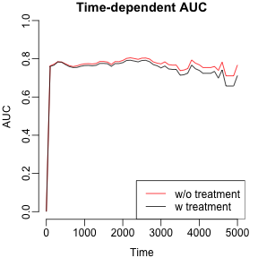

```r
# barplot(c(CGP=survConcordance(survivalTD[!testIxTD] ~ predictiveRiskTest)$concordance, MolecularRisk =
# survConcordance(survivalTD[!testIxTD] ~ c(Favourable=1, Adverse=4, `inter-1`=2,
# `inter-2`=3)[clinicalData$M_Risk[tplSplit][!testIxTD]])[[1]]))

s <- survival[!trainIdx]
plot(AUC.uno(s[!is.na(s)], s[!is.na(s)], predictiveRiskTest[!is.na(s)], seq(0, 5000, 100)))
plot(AUC.uno(s[!is.na(s)], s[!is.na(s)], totalRiskTest[!is.na(s)], seq(0, 5000, 100)), add = TRUE, col = "black")
legend("bottomright", c("w/o treatment", "w treatment"), col = 2:1, lty = 1)
```

### 3. Recursive partitioning & randomForestSRC

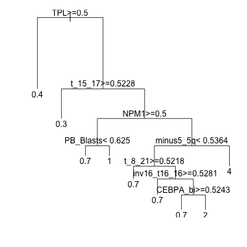

```r
library(rpart)
library(randomForestSRC)
tree <- rpart(survival ~ ., data = dataFrame[mainIdx])
plot(tree)
text(tree)
```

```r
survConcordance(na.omit(survival) ~ predict(tree))
```

```
## Call:
## survConcordance(formula = na.omit(survival) ~ predict(tree))
##
##   n= 1545
## Concordance= 0.7168 se= 0.008919
## concordant discordant  tied.risk  tied.time   std(c-d)
##     657729     189172     233484       3500      19272
```

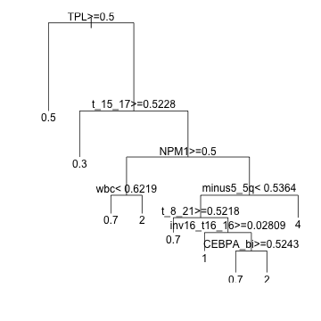

```r
treeCV <- rpart(survival[trainIdx] ~ ., data = dataFrame[trainIdx, mainIdx])
plot(treeCV)
text(treeCV)
```

```r
survConcordance(survival[!trainIdx] ~ predict(treeCV, newdata = dataFrame[!trainIdx, mainIdx]))
```

```
## Call:
## survConcordance(formula = survival[!trainIdx] ~ predict(treeCV,
##     newdata = dataFrame[!trainIdx, mainIdx]))
##
##   n=512 (10 observations deleted due to missingness)
## Concordance= 0.7231 se= 0.01551
## concordant discordant  tied.risk  tied.time   std(c-d)
##      74815      21729      22435        388       3691
```

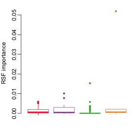

```r
rForest <- rfsrc(Surv(time, status) ~ ., data = cbind(time = survival[, 1], status = survival[, 2], dataFrame[, mainIdx]),
    ntree = 100)
boxplot(rForest$importance ~ factor(as.character(groups[mainIdx])), border = col1, staplewex = 0, pch = 16, cex = 0.75, ylab = "RSF importance",
    lty = 1, xaxt = "n")
```

```r
sapply(mainGroups, function(g) vimp(rForest, colnames(dataFrame)[which(groups == g)]))
```

[output not shown]

```r
survConcordance(na.omit(survival) ~ predict(rForest, importance = "none")$predicted)
```

```
## Call:
## survConcordance(formula = na.omit(survival) ~ predict(rForest,
##     importance = "none")$predicted)
##
##   n= 1545
## Concordance= 0.8891 se= 0.0092
## concordant discordant  tied.risk  tied.time   std(c-d)
##     960518     119867          0       3500      19879
```

```r
rForestCV <- rfsrc(Surv(time, status) ~ ., data = cbind(time = survival[, 1], status = survival[, 2], dataFrame[, mainIdx])[trainIdx,
    ], ntree = 100, importance = "none")
p <- predict(rForestCV, newdata = dataFrame[!trainIdx, mainIdx], importance = "none")
survConcordance(survival[!trainIdx] ~ p$predicted)
```

```
## Call:
## survConcordance(formula = survival[!trainIdx] ~ p$predicted)
##
##   n=512 (10 observations deleted due to missingness)
## Concordance= 0.738 se= 0.01594
## concordant discordant  tied.risk  tied.time   std(c-d)
##      87810      31169          0        388       3792
```

### 4. Stability selection: All terms

```r
library(parallel)
library(glmnet)
source("../../CoxHD/CoxHD/R/CoxCPSS.R")
source("../../CoxHD/CoxHD/R/r_concave_tail.R")
```

Fit model

```r
set.seed(42)
coxCPSS <- CoxCPSS(dataFrame[!is.na(survival), ], survival[!is.na(survival)], bootstrap.samples = 50, control = "BH", level = 0.1)
```

```
## ..................................................
```

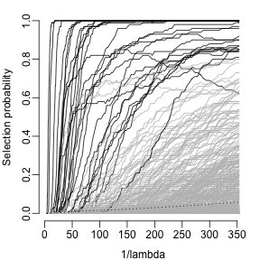

```r
plot(coxCPSS)
```

```r
selected <- which(coxCPSS$Pi > 0.8)
selected
```

```
##            DNMT3A              IDH1              NPM1             SF3B1             SFRS2              TP53
##                10                17                32                43                44                48
##        CEBPA_mono          CEBPA_bi          FLT3_ITD         inv3_t3_3         minus5_5q            minus7
##                53                54                55                60                62                63
## mono17_17p_abn17p           t_15_17            t_8_21      inv16_t16_16            tr0704               TPL
##                70                76                77                78                84                87
##               AOD            gender  Performance_ECOG         PB_Blasts               wbc              LDH_
##                88                89                90                92                93                94
##       DNMT3A:IDH2     NPM1:FLT3_ITD     NPM1:FLT3_TKD          TPL:NPM1
##               150               680               719              1402
```

```r
coxFit <- coxph(survival[trainIdx] ~ ., data = dataFrame[trainIdx, ][, names(selected)])
summary(coxFit)
```

```
## Call:
## coxph(formula = survival[trainIdx] ~ ., data = dataFrame[trainIdx,
##     ][, names(selected)])
##
##   n= 1033, number of events= 750
##    (21 observations deleted due to missingness)
##
##                      coef exp(coef) se(coef)      z Pr(>|z|)
## DNMT3A             0.0916    1.0959   0.1047   0.87  0.38209
## IDH1               0.1620    1.1759   0.1536   1.05  0.29149
## NPM1              -1.0972    0.3338   0.1343  -8.17  3.3e-16 ***
## SF3B1              0.4748    1.6077   0.2201   2.16  0.03100 *
## SFRS2              0.5936    1.8106   0.1521   3.90  9.5e-05 ***
## TP53               0.3263    1.3858   0.1946   1.68  0.09365 .
## CEBPA_mono        -0.5682    0.5666   0.2162  -2.63  0.00857 **
## CEBPA_bi          -1.1109    0.3293   0.2255  -4.93  8.4e-07 ***
## FLT3_ITD           0.3241    1.3827   0.1232   2.63  0.00854 **
## inv3_t3_3          1.1711    3.2257   0.3465   3.38  0.00072 ***
## minus5_5q          0.5412    1.7180   0.1847   2.93  0.00338 **
## minus7             0.3141    1.3690   0.1836   1.71  0.08717 .
## mono17_17p_abn17p  0.3362    1.3997   0.2138   1.57  0.11587
## t_15_17           -2.1485    0.1167   0.2899  -7.41  1.3e-13 ***
## t_8_21            -0.9222    0.3976   0.2048  -4.50  6.7e-06 ***
## inv16_t16_16      -1.0620    0.3458   0.2082  -5.10  3.4e-07 ***
## tr0704            -0.1293    0.8787   0.0786  -1.65  0.09981 .
## TPL               -1.4543    0.2336   0.1300 -11.18  < 2e-16 ***
## AOD                0.0341    1.0347   0.0327   1.04  0.29732
## gender            -0.1638    0.8489   0.0776  -2.11  0.03472 *
## Performance_ECOG   0.0318    1.0324   0.0629   0.51  0.61265
## PB_Blasts          0.3464    1.4140   0.1427   2.43  0.01517 *
## wbc                0.2617    1.2992   0.0835   3.14  0.00171 **
## LDH_               0.0764    1.0794   0.0641   1.19  0.23319
## `DNMT3A:IDH2`      0.3991    1.4905   0.1993   2.00  0.04529 *
## `NPM1:FLT3_ITD`    0.4590    1.5825   0.1932   2.38  0.01750 *
## `NPM1:FLT3_TKD`   -0.4256    0.6534   0.2519  -1.69  0.09112 .
## `TPL:NPM1`         0.4916    1.6349   0.2296   2.14  0.03227 *
## ---
## Signif. codes:  0 '***' 0.001 '**' 0.01 '*' 0.05 '.' 0.1 ' ' 1
##
##                   exp(coef) exp(-coef) lower .95 upper .95
```

[output cut: 19 more lines]

```
## gender                0.849      1.178    0.7292     0.988
## Performance_ECOG      1.032      0.969    0.9126     1.168
## PB_Blasts             1.414      0.707    1.0691     1.870
## wbc                   1.299      0.770    1.1032     1.530
## LDH_                  1.079      0.926    0.9520     1.224
## `DNMT3A:IDH2`         1.490      0.671    1.0084     2.203
## `NPM1:FLT3_ITD`       1.582      0.632    1.0837     2.311
## `NPM1:FLT3_TKD`       0.653      1.530    0.3988     1.070
## `TPL:NPM1`            1.635      0.612    1.0425     2.564
##
## Concordance= 0.75  (se = 0.011 )
## Rsquare= 0.41   (max possible= 1 )
## Likelihood ratio test= 545  on 28 df,   p=0
## Wald test            = 505  on 28 df,   p=0
## Score (logrank) test = 588  on 28 df,   p=0
```

```r
totalRiskStabTest <- as.matrix(dataFrame[!trainIdx, ][, names(selected)]) %*% coxFit$coefficients
survConcordance(survival[!trainIdx] ~ totalRiskStabTest)
```

```
## Call:
## survConcordance(formula = survival[!trainIdx] ~ totalRiskStabTest)
##
##   n=512 (10 observations deleted due to missingness)
## Concordance= 0.7622 se= 0.01594
## concordant discordant  tied.risk  tied.time   std(c-d)
##      90688      28291          0        388       3792
```

### 5. Stability selection with interactions

Only include interaction terms when main effects are present. On the other hand, the exclusive selection of a product term could mean that the most likely explanation is that the two main terms are zero and only the interaction is non-zero..

```r
CoxCPSSInteractions
```

```
## function(X, surv, scope = 1:ncol(X),...){
##  #R <- apply(X, 2, sample)
##  #s1 <- StabCox(cbind(X,R=R), surv, control="BH", which.error = ncol(X) + 1:ncol(X), ...)
##  s1 <- CoxCPSS(X, surv, control="BH")
##  w <- which(s1$Pi > s1$pi.thr)
##  i <- intersect(scope, w)
##  I <- makeInteractions(X[,i],X[,i])[,as.vector(upper.tri(matrix(0,ncol=length(i), nrow=length(i))))]
##  I <- I[,colSums(I) > 0]
##  Z <- cbind(X, I)
##  #R <- apply(Z, 2, sample)
##  #Z <- cbind(Z, R=R)
##  penalty <- rep(1, ncol(Z))
##  penalty[i] <- 0
##  #StabCox(Z, surv, penalty.factor = penalty, control = "BH", which.error = (ncol(X) + ncol(I) + 1):ncol(Z) , ...)
##  CoxCPSS(Z, surv, penalty.factor = penalty, control = "BH", ...)
## }
```

#### Fit model to entire data set

```r
set.seed(42)
coxCPSSInt <- CoxCPSSInteractions(dataFrame[!is.na(survival), groups %in% mainGroups], na.omit(survival), bootstrap.samples = 50,
    scope = which(groups %in% c("Genetics", "Cytogenetics", "Treatment")))
```

```
## ..................................................
```

```
## ..................................................
```

```r
selectedInt <- names(which(coxCPSSInt$Pi > 0.8))
selectedInt[21] <- "TPL:NPM1"
```

Concordance of the resulting static coxph model

```r
coxFit <- coxph(survival[trainIdx] ~ ., data = dataFrame[trainIdx, selectedInt])
summary(coxFit)
```

```
## Call:
## coxph(formula = survival[trainIdx] ~ ., data = dataFrame[trainIdx,
##     selectedInt])
##
##   n= 1033, number of events= 750
##    (21 observations deleted due to missingness)
##
##                      coef exp(coef) se(coef)      z Pr(>|z|)
## DNMT3A             0.1530    1.1654   0.0968   1.58   0.1138
## NPM1              -1.1936    0.3031   0.1295  -9.22  < 2e-16 ***
## SFRS2              0.5571    1.7457   0.1498   3.72   0.0002 ***
## TP53               0.2895    1.3358   0.1916   1.51   0.1307
## CEBPA_mono        -0.6335    0.5307   0.2147  -2.95   0.0032 **
## CEBPA_bi          -1.2145    0.2968   0.2235  -5.43  5.5e-08 ***
## FLT3_ITD           0.2446    1.2771   0.1221   2.00   0.0451 *
## minus5_5q          0.5074    1.6609   0.1821   2.79   0.0053 **
## minus7             0.4536    1.5740   0.1716   2.64   0.0082 **
## mono17_17p_abn17p  0.2802    1.3234   0.2119   1.32   0.1859
## t_15_17           -2.1675    0.1145   0.2895  -7.49  7.0e-14 ***
## t_8_21            -0.9667    0.3803   0.2036  -4.75  2.0e-06 ***
## inv16_t16_16      -1.1611    0.3132   0.2067  -5.62  2.0e-08 ***
## tr0704            -0.1113    0.8946   0.0782  -1.42   0.1543
## TPL               -1.4763    0.2285   0.1297 -11.38  < 2e-16 ***
## AOD                0.0372    1.0379   0.0320   1.16   0.2457
## gender            -0.1801    0.8352   0.0767  -2.35   0.0188 *
## PB_Blasts          0.4188    1.5201   0.1370   3.06   0.0022 **
## wbc                0.3434    1.4097   0.0779   4.41  1.0e-05 ***
## `NPM1:FLT3_ITD`    0.5408    1.7174   0.1904   2.84   0.0045 **
## `TPL:NPM1`         0.4741    1.6066   0.2279   2.08   0.0375 *
## ---
## Signif. codes:  0 '***' 0.001 '**' 0.01 '*' 0.05 '.' 0.1 ' ' 1
##
##                   exp(coef) exp(-coef) lower .95 upper .95
## DNMT3A                1.165      0.858    0.9640     1.409
## NPM1                  0.303      3.299    0.2352     0.391
## SFRS2                 1.746      0.573    1.3016     2.341
## TP53                  1.336      0.749    0.9176     1.945
## CEBPA_mono            0.531      1.884    0.3484     0.808
## CEBPA_bi              0.297      3.369    0.1916     0.460
## FLT3_ITD              1.277      0.783    1.0053     1.622
## minus5_5q             1.661      0.602    1.1623     2.373
## minus7                1.574      0.635    1.1245     2.203
## mono17_17p_abn17p     1.323      0.756    0.8737     2.005
## t_15_17               0.114      8.736    0.0649     0.202
## t_8_21                0.380      2.629    0.2552     0.567
## inv16_t16_16          0.313      3.193    0.2088     0.470
## tr0704                0.895      1.118    0.7676     1.043
## TPL                   0.228      4.377    0.1772     0.295
## AOD                   1.038      0.964    0.9747     1.105
## gender                0.835      1.197    0.7186     0.971
## PB_Blasts             1.520      0.658    1.1621     1.988
## wbc                   1.410      0.709    1.2101     1.642
## `NPM1:FLT3_ITD`       1.717      0.582    1.1825     2.494
## `TPL:NPM1`            1.607      0.622    1.0279     2.511
##
## Concordance= 0.745  (se = 0.011 )
## Rsquare= 0.398   (max possible= 1 )
## Likelihood ratio test= 524  on 21 df,   p=0
## Wald test            = 473  on 21 df,   p=0
## Score (logrank) test = 532  on 21 df,   p=0
```

```r
survConcordance(survival[!trainIdx] ~ predict(coxFit, newdata = dataFrame[!trainIdx, selectedInt]))
```

```
## Call:
## survConcordance(formula = survival[!trainIdx] ~ predict(coxFit,
##     newdata = dataFrame[!trainIdx, selectedInt]))
##
##   n=512 (10 observations deleted due to missingness)
## Concordance= 0.7607 se= 0.01594
## concordant discordant  tied.risk  tied.time   std(c-d)
##      90513      28466          0        388       3792
```

Concordance of the corresponding time-dependent coxph model

```r
coxFitTD <- coxph(survivalTD[trainIdxTD] ~ ., data = dataFrameTD[trainIdxTD, selectedInt])
summary(coxFitTD)
```

```
## Call:
## coxph(formula = survivalTD[trainIdxTD] ~ ., data = dataFrameTD[trainIdxTD,
##     selectedInt])
##
##   n= 1255, number of events= 750
##    (21 observations deleted due to missingness)
##
##                      coef exp(coef) se(coef)     z Pr(>|z|)
## DNMT3A             0.1956    1.2160   0.0972  2.01   0.0442 *
## NPM1              -1.1357    0.3212   0.1311 -8.66  < 2e-16 ***
## SFRS2              0.4718    1.6030   0.1492  3.16   0.0016 **
## TP53               0.4464    1.5626   0.1927  2.32   0.0205 *
## CEBPA_mono        -0.5924    0.5530   0.2148 -2.76   0.0058 **
## CEBPA_bi          -1.1873    0.3050   0.2216 -5.36  8.4e-08 ***
## FLT3_ITD           0.1968    1.2174   0.1218  1.62   0.1063
## minus5_5q          0.3600    1.4333   0.1891  1.90   0.0569 .
## minus7             0.3182    1.3746   0.1803  1.76   0.0776 .
## mono17_17p_abn17p  0.0631    1.0651   0.2242  0.28   0.7784
## t_15_17           -1.8384    0.1591   0.2879 -6.39  1.7e-10 ***
## t_8_21            -0.7188    0.4873   0.2032 -3.54   0.0004 ***
## inv16_t16_16      -1.1289    0.3234   0.2042 -5.53  3.2e-08 ***
## tr0704            -0.0768    0.9260   0.0773 -0.99   0.3202
## TPL               -0.6673    0.5131   0.1391 -4.80  1.6e-06 ***
## AOD                0.0978    1.1028   0.0322  3.04   0.0024 **
## gender            -0.1665    0.8466   0.0769 -2.17   0.0304 *
## PB_Blasts          0.3738    1.4533   0.1371  2.73   0.0064 **
## wbc                0.3765    1.4572   0.0777  4.84  1.3e-06 ***
## `NPM1:FLT3_ITD`    0.4740    1.6065   0.1899  2.50   0.0126 *
## `TPL:NPM1`         0.3216    1.3793   0.2264  1.42   0.1554
## ---
## Signif. codes:  0 '***' 0.001 '**' 0.01 '*' 0.05 '.' 0.1 ' ' 1
##
##                   exp(coef) exp(-coef) lower .95 upper .95
## DNMT3A                1.216      0.822    1.0051     1.471
## NPM1                  0.321      3.113    0.2484     0.415
## SFRS2                 1.603      0.624    1.1965     2.148
## TP53                  1.563      0.640    1.0712     2.280
## CEBPA_mono            0.553      1.808    0.3630     0.842
## CEBPA_bi              0.305      3.278    0.1976     0.471
## FLT3_ITD              1.217      0.821    0.9589     1.546
## minus5_5q             1.433      0.698    0.9895     2.076
## minus7                1.375      0.727    0.9654     1.957
## mono17_17p_abn17p     1.065      0.939    0.6864     1.653
## t_15_17               0.159      6.287    0.0905     0.280
## t_8_21                0.487      2.052    0.3272     0.726
## inv16_t16_16          0.323      3.092    0.2167     0.483
## tr0704                0.926      1.080    0.7958     1.078
## TPL                   0.513      1.949    0.3907     0.674
## AOD                   1.103      0.907    1.0353     1.175
## gender                0.847      1.181    0.7282     0.984
## PB_Blasts             1.453      0.688    1.1109     1.901
## wbc                   1.457      0.686    1.2513     1.697
## `NPM1:FLT3_ITD`       1.606      0.622    1.1072     2.331
## `TPL:NPM1`            1.379      0.725    0.8851     2.150
##
## Concordance= 0.7  (se = 0.011 )
## Rsquare= 0.245   (max possible= 1 )
## Likelihood ratio test= 352  on 21 df,   p=0
## Wald test            = 338  on 21 df,   p=0
## Score (logrank) test = 371  on 21 df,   p=0
```

```r
survConcordance(survivalTD[!trainIdxTD] ~ predict(coxFitTD, newdata = dataFrameTD[!trainIdxTD, selectedInt]))
```

```
## Call:
## survConcordance(formula = survivalTD[!trainIdxTD] ~ predict(coxFitTD,
##     newdata = dataFrameTD[!trainIdxTD, selectedInt]))
##
##   n=621 (10 observations deleted due to missingness)
## Concordance= 0.7162 se= 0.01594
## concordant discordant  tied.risk  tied.time   std(c-d)
##      85216      33763          0        388       3792
```

KM plots of interaction terms

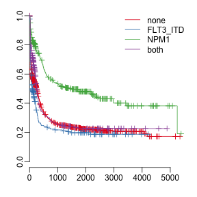

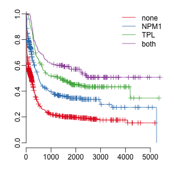

```r
for (i in grep(":", selectedInt, value = TRUE)) {
    j <- strsplit(i, ":")[[1]]
    plot(survfit(as.formula(paste("survivalTD ~ ", paste(j, collapse = "+"))), data = dataFrameTD), col = set1)
    legend("topright", lty = 1, col = set1, c("none", rev(j), "both"), bty = "n")
}
```

Plots of the stability selection: No large difference between when interaction terms are enforce to only occur after main effects are included

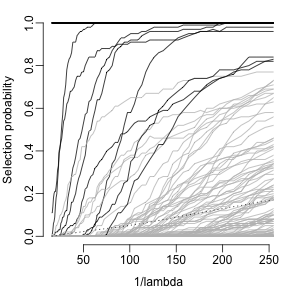

```r
plot(coxCPSSInt)
```

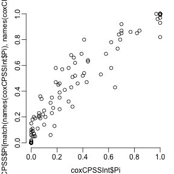

```r
plot(coxCPSSInt$Pi, coxCPSS$Pi[match(names(coxCPSSInt$Pi), names(coxCPSS$Pi))])
```

```r
names(groups) <- colnames(dataFrame)
X <- as.matrix(dataFrameTD[selectedInt])
X <- X - rep(colMeans(X), each = nrow(X))
partRiskCoxCPSSInt <- sapply(levels(groups), function(l) {
    w <- groups[selectedInt] == l
    if (length(w) > 0)
        X[, w, drop = FALSE] %*% coef(coxFitTD)[w] else rep(0, nrow(X))
})
```

Genomic risk

```r
whichGenomicCoxCPSSInt <- which(!colnames(partRiskCoxCPSSInt) %in% c("Treatment", "GeneTreat", "CytoTreat", "Clinical"))
genomicRiskCoxCPSSInt <- rowSums(partRiskCoxCPSSInt[, whichGenomicCoxCPSSInt])
survConcordance(survivalTD ~ genomicRiskCoxCPSSInt)
```

```
## Call:
## survConcordance(formula = survivalTD ~ genomicRiskCoxCPSSInt)
##
##   n=1876 (31 observations deleted due to missingness)
## Concordance= 0.6803 se= 0.009154
## concordant discordant  tied.risk  tied.time   std(c-d)
##     698039     308444      73902       3500      19780
```